# Факторы среды и сообщества планктона Обской губы

# Факторы среды

В данной версии анализа использованы материалы сборов августа 2020 г.

## Обозначения переменных

Принятые в анализе обозначения переменных среды приведены в таблице 1.

Таблица 1. Обозначения переменных

| **Переменная** | **Содержание** |
| --- | --- |
| Station | Станция |
| Lat | Широта (N) |
| Long | Долгота (E) |
| Depth | Глубина по эхолоту, м |
| Transparency | Прозрачность, м |
| Surf_Salinity | Соленость_пов [psu] |
| Bot_Salinity | Соленость_дно [psu] |
| Surf_Turbidity | Мутность_пов [NTU] |
| Bot_Turbidity | Мутность_дно [NTU] |
| Surf_Susp | Взвешенные вещества, мг/л поверхностный слой |
| Interm_Susp | Взвешенные вещества, мг/л промежуточный слой |
| Bot_Susp | Взвешенные вещества, мг/л придонный слой |
| Chla_surface | Концентрация хлорофилла а (мкг/л) в поверхностно слое |
| Chla_intermed | Концентрация хлорофилла а (мкг/л) в промежуточном слое |
| Chla_bottom | Концентрация хлорофилла а (мкг/л) в придонном слое |
| Org | Концентрация органического вещества в грунте (%) |
| Fine_particles | Доля мелкой фракции грунта (диаметр меньше 0.05 мм) |
| Coarce_particles | Доля крупной фракции грунта (диаметр больше 0.05 мм) |
| Bot_Color | Цветность, градус в придонном слое воды |
| Bot_O2 | О2, мгО2/куб. дм в придонном слое воды |
| Bot_pH | рН в придонном слое воды |
| Bot_Amon_N | Азот Аммоний, мкг/л в придонном слое воды |
| Bot_Nitrit_N | Азот нитритный, мкг/л в придонном слое воды |
| Bot_Nitrat_N | Азот нитратный, мкг/л в придонном слое воды |
| Bot_Total_N | Азот общий, мкг/л в придонном слое воды |
| Bot_Mineral_P | Фосфор минеральный мкг/л в придонном слое воды |
| Bot_Total_P | Фосфор общий, мкг/л в придонном слое воды |
| Bot_Si | Кремний, мкг/л в придонном слое воды |
| Bot_Organic_N | Азот органический, мкг/л в придонном слое воды |
| Bot_Organic_P | фосфор органический, мкг/л в придонном слое воды |
| Int_Color | Цветность, градус в промежуточном слое воды |
| Int_O2 | О2, мгО2/куб. дм в промежуточном слое воды |
| Int_pH | рН в промежуточном слое воды |
| Int_Amon_N | Азот Аммоний, мкг/л в промежуточном слое воды |
| Int_Nitrit_N | Азот нитритный, мкг/л в промежуточном слое воды |
| Int_Nitrat_N | Азот нитратный, мкг/л в промежуточном слое воды |
| Int_Total_N | Азот общий, мкг/л в промежуточном слое воды |
| Int_Mineral_P | Фосфор минеральный мкг/л в промежуточном слое воды |
| Int_Total_P | Фосфор общий, мкг/л в промежуточном слое воды |
| Int_Si | Кремний, мкг/л в промежуточном слое воды |
| Int_Organic_N | Азот органический, мкг/л в промежуточном слое воды |
| Int_Organic_P | фосфор органический, мкг/л в промежуточном слое воды |
| Surf_Color | Цветность, градус в поверхностном слое воды |
| Surf_O2 | О2, мгО2/куб. дм в поверхностном слое воды |
| Surf_pH | рН в поверхностном слое воды |
| Surf_Amon_N | Азот Аммоний, мкг/л в поверхностном слое воды |
| Surf_Nitrit_N | Азот нитритный, мкг/л в поверхностном слое воды |
| Surf_Nitrat_N | Азот нитратный, мкг/л в поверхностном слое воды |
| Surf_Total_N | Азот общий, мкг/л в поверхностном слое воды |
| Surf_Mineral_P | Фосфор минеральный мкг/л в поверхностном слое воды |
| Surf_Total_P | Фосфор общий, мкг/л в поверхностном слое воды |
| Surf_Si | Кремний, мкг/л в поверхностном слое воды |
| Surf_Organic_N | Азот органический, мкг/л в поверхностном слое воды |
| Surf_Organic_P | фосфор органический, мкг/л в поверхностном слое воды |
| Ships | Судовая нагрузка |
| Distance_Dump | Расстояние до точек отвала грунта |
| Distance_to_Drag | Расстояние до точек дноуглубления |

## Подготовка данных

В нескольких переменных были отмечены неизмеренные значения (Табл.2). Поскольку дальнейший анализ чувствителен к пропущенным значениям, пропуски были заполнены средними значениями.

**NB!** Возможны более тонкие способы заполнения пропусков (предсказания на основе регрессионных моделей или Singular Spectral Analysis). Однако для их использования необходимо обсудить целесообразность применения этих методов. Еще одно возможное решение - это удаление из анализа материала станций, в которых были отмечены пропуски. В этом случае придется удалить 36 станций.

Таблица 2. Количество пропущенных значений для разных переменных

| Переменная | Количество станций, на которых отсутствуют измерения |
| --- | --- |
| Interm_Susp | 26 |
| Bot_Susp | 7 |
| Chla_surface | 8 |
| Chla_intermed | 36 |
| Chla_bottom | 18 |
| Bot_Color | 9 |
| Bot_O2 | 9 |
| Bot_pH | 9 |
| Bot_Amon_N | 9 |
| Bot_Nitrit_N | 9 |
| Bot_Nitrat_N | 9 |
| Bot_Total_N | 9 |
| Bot_Mineral_P | 9 |
| Bot_Total_P | 9 |
| Bot_Si | 9 |
| Bot_Organic_N | 9 |
| Bot_Organic_P | 9 |
| Int_Color | 24 |
| Int_O2 | 24 |
| Int_pH | 24 |
| Int_Amon_N | 24 |
| Int_Nitrit_N | 24 |
| Int_Nitrat_N | 24 |
| Int_Total_N | 24 |
| Int_Mineral_P | 24 |
| Int_Total_P | 24 |
| Int_Si | 24 |
| Int_Organic_N | 24 |
| Int_Organic_P | 24 |

Ниже приводятся карты, отражающие пространственное распределение параметров, которые дополняют карты, приведенные в следующих файлах: Bac_посевы_Н_b.pdf, Bac_посевы_Н_m.pdf, Bac_посевы_Н_s.pdf, Bac_посевы_С_b.pdf, Bac_посевы_С_m.pdf, Bac_посевы_С_s.pdf, Bac_посевы_Ф_b.pdf, Bac_посевы_Ф_m.pdf, Bac_посевы_Ф_s.pdf, Chlor_aug_b (1).jpg, Chlor_aug_b (1).pdf, Chlor_aug_m (1).jpg, Chlor_aug_m (1).pdf, Chlor_aug_s (1).jpg, Chlor_aug_s (1).pdf, Chlor_modis_august (1).jpg, Chlor_modis_july (1).jpg, Chlor_modis_june (1).jpg, Chlor_modis_september (1).jpg, NDVI.pdf, Sent_Visual.pdf, Susp_aug_b.pdf, Susp_aug_m.pdf, Susp_aug_s.pdf, Susp_Sentinel (1).pdf, Susp_sept_b.pdf, Susp_sept_m.pdf, Susp_sept_s.pdf, Зоо_биомасса.pdf, Зоо_биомасса_оранж.pdf, Зоо_численность.pdf

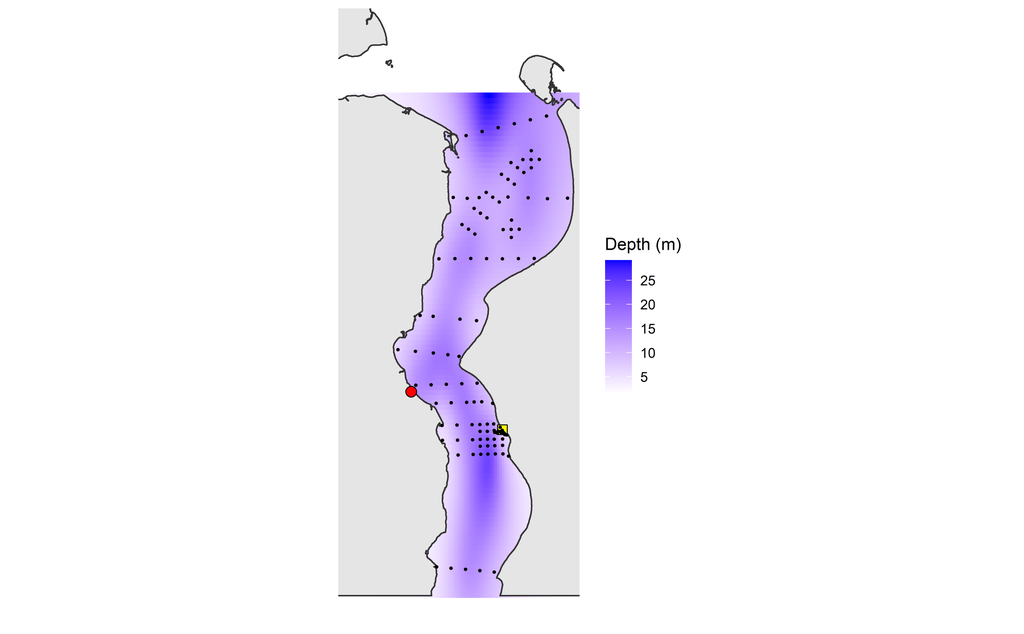

**Рисунок 1.** Глубина в районе проведения работ.

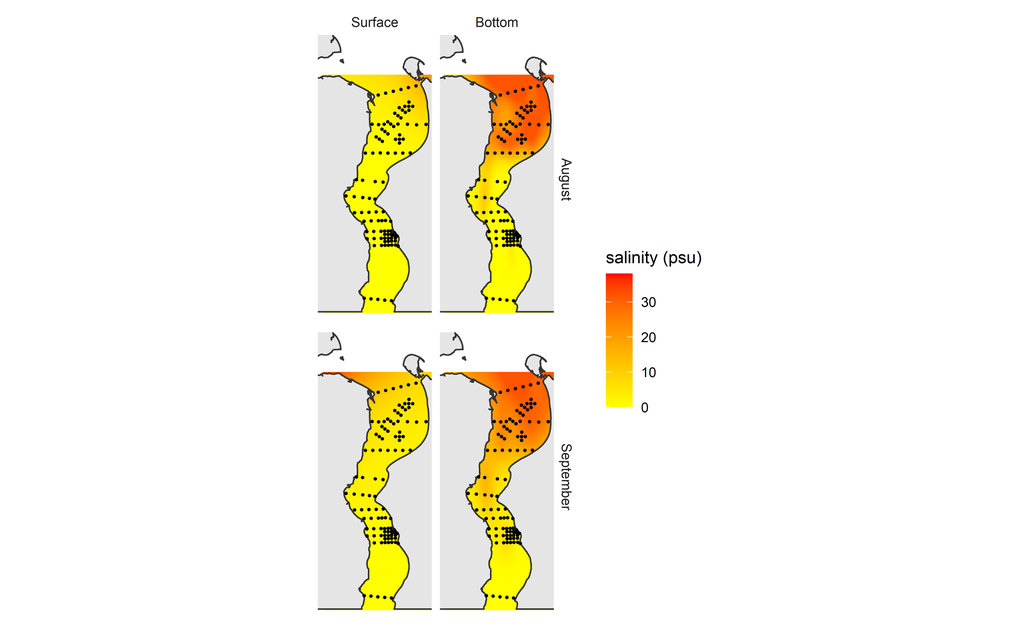

**Рисунок 2.** Соленость в районе проведения работ.

## Гранулометрический состав грунта

Для более компактного описания гранулометрического состава донного осадка был проведен анализ главных компонент. Анализ был основан на матрице долей 13фракций грунта, выделенных на основе размера частиц. Результаты анализа отражает Рисунок 3.

Первая главная компонента описывает значительную часть варьирования исходных переменных (72% суммарной дисперсии). Наиболее высокие положительные значения нагрузок по PC1 приходятся на самые мелкие фракции грунта (диаметр частиц менее 0.05 мм), а наибольшие отрицательные нагрузки по этой компоненте имеют фракции более крупные фракции. В связи с этим можно разделить все фракции грунта на две группы: *мелкие фракции* (диаметр частиц меньше 0.05 мм) и *крупные фракции* (размер частиц более 0.05 мм). Пространственное распределение двух обобщенных фракций демонстрируют карты, приведенные на Рисунок 4.

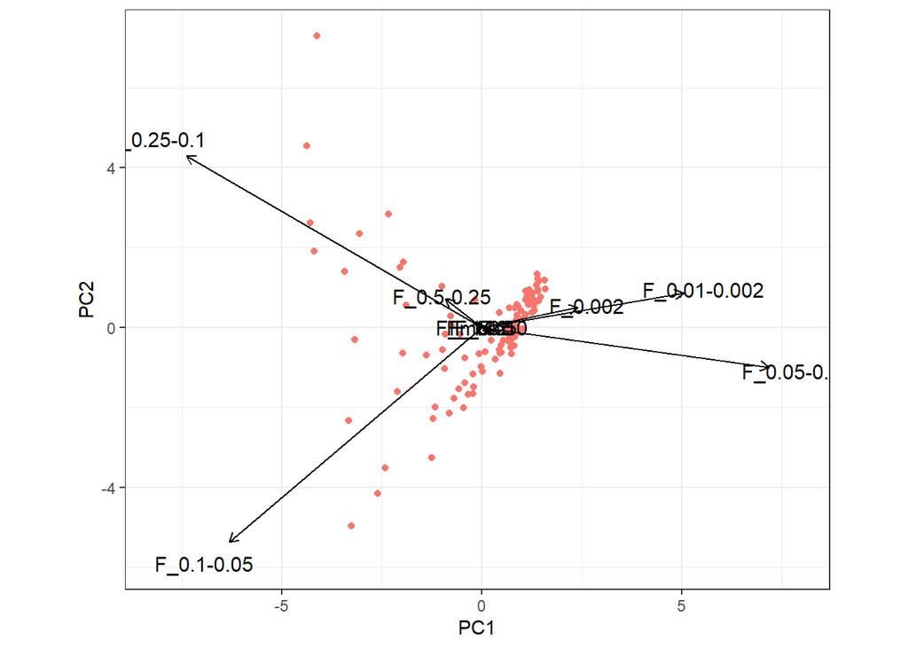

**Рисунок 3.** Ординация проб в осях первых двух главных компонент и нагрузки переменных, использованных в анализе главных компонент матрицы гранулометрического состава

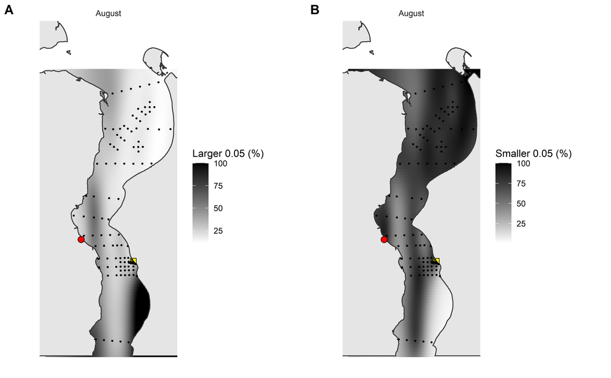

**Рисунок 4.** Распределение крупных (A) и мелких (B) фракций грунта в акватории Обской губы.

# Судовая нагрузка

*NB! Методика получения судовой нагрузки пока мне непонятна.*

Оценка судовой нагрузки в каждой из точек проводилась по спутниковым снимкам.

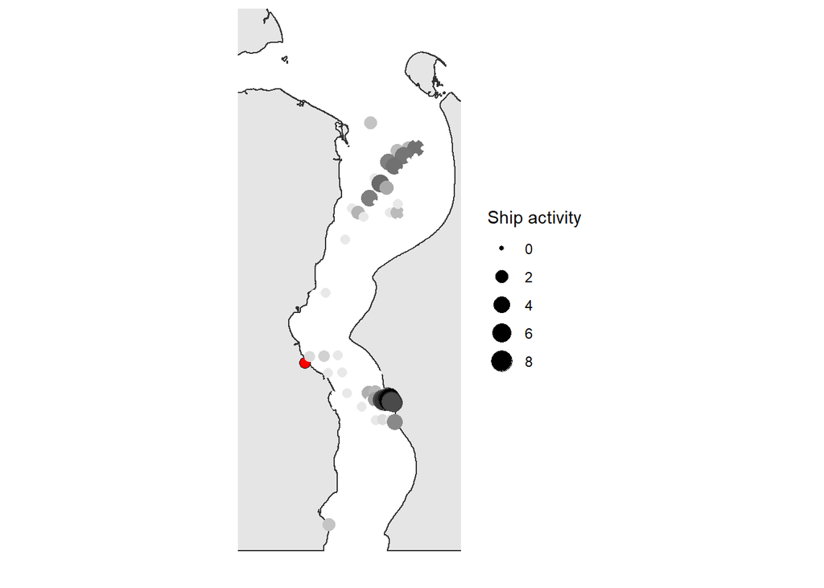

**Рисунок 5.** Распределение оценок судовой нагрузки для каждой станции. Отражены значения логарифма оценки

# Факторы, определяющие количество взвеси

| term | estimate | std.error | statistic | p.value |
| --- | --- | --- | --- | --- |
| (Intercept) | 4.9405689 | 0.1154194 | 42.805351 | 0.0000000 |
| Ships | 0.0001448 | 0.0000851 | 1.700260 | 0.0922055 |
| Distance_Dump | 0.0000196 | 0.0000081 | 2.428464 | 0.0169580 |
| Distance_to_Drag | -0.0000259 | 0.0000072 | -3.583302 | 0.0005272 |

# Сообщества зоопланктона

Для анализа связи сообщества зоопланктона с изученными параметрами среды был использован канонический корреспондентный анализ (Canonical Correspondence Analysis, CCA). Для построения оптимальной модели CCA был использован алгоритм пошагового подбора предикторов (forward selection). Финальная модель, полученная в результате анализа, включала 14 параметров среды. Характер связи с ними демонстрирует Рисунок 6.

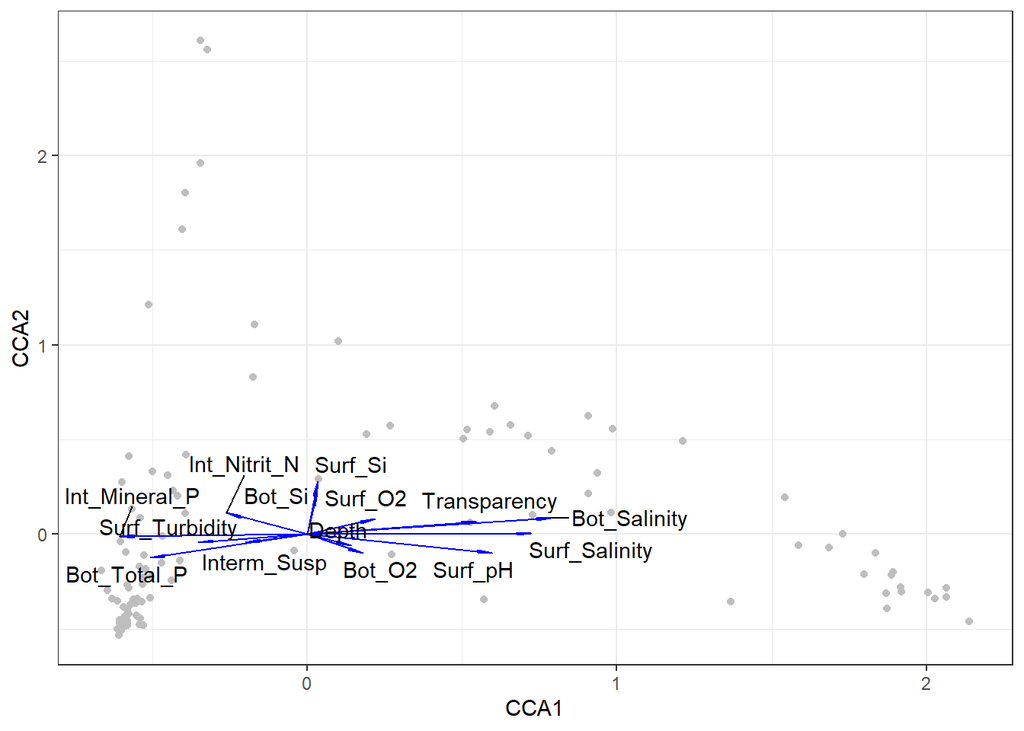

**Рисунок 6.** Ординация проб в первой и второй канонических корреспондентных осях

Статистическую значимость имели только три первые корресподнетные оси, которые описывают 23.4, 7.8, 5% суммарной изменчивости, соответственно. Согласно полученным результатам, первая корреспондентная ось имеет высокую корреляцию c Bot_Salinity, Surf_Salinity, Surf_pH, Transparency, Surf_O2. Высокие положительные значения первой канонической оси могут трактоваться как отражение влияния притока морской воды. Водная масса морского происхождения характеризуется высокой прозрачностью и низкой кислотностью (высокие значения pH). Высокую отрицательную корреляцию с первой канонической осью демонстрируют следующие параметры среды: Int_Mineral_P, Bot_Total_P, Surf_Turbidity, Int_Nitrit_N, Interm_Susp. Эти параметры имеют высокие значения водных массах речного происхождения. Это более мутные, с бльшим количеством взвеси, богатые азотом и фосфором воды.

Пространственное распределение значений CCA1 демонстрирует Рисунок 7. Ожидаемо положительные значения ССА1, соответствующие морским сообществам зоопланктона, приурочены к устью Обской губы. Следует отметить, что в распределении сообществ, описанных в терминах ССА1 (Рисунок 7), заметна некоторая пятнистость, что можно объяснить перемещением водных масс в результате взаимодействия речного и приливно-отливного течений.

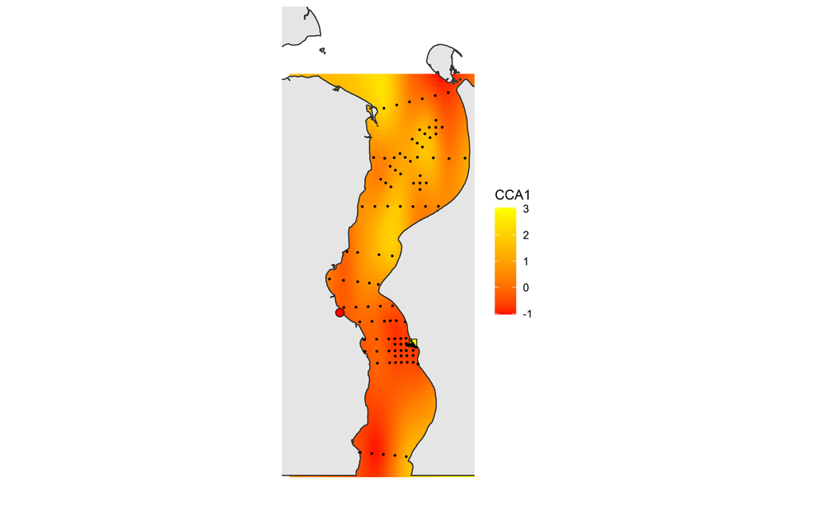

**Рисунок 7.** Распределние сообществ зоопланктона, охараткеризованных значениям первой корреспондентной оси, демонстрирующей связи с параметрами водных масс морского и речного происхождения

К числу видов, характерных для водной массы морского происхождения относятся:

| Таксоны |
| --- |
| Acartia longiremis |
| Acartia sp. |
| Bivalvia larvae |
| Calanus glacialis |
| Cerianthus sp. |
| Harpacticus uniremis |
| Jaschnovia tolli |
| Larvae Polychaeta |
| Mesochra lilljeborgii |
| Microsetella norvegica |
| Nauplia Acartia |
| Nauplia Pseudocalanus |
| Nauplia Temora |
| Obelia longissima |
| Oithona similis |
| Pseudocalanus acuspes |
| Rathkea octopunctata |
| Senecella calanoides |
| Synchaeta tamara |
| Temora longicornis |

*Замечание: Приведены только таксоны имеющие нагрузки по CCA1, превышающие значение третьего квартиля.*

К числу видов, характерных для водной массы речного происхождения относятся:

| Таксоны |
| --- |
| Acanthocyclops vernalis |
| Arctodiaptomus bacillifer |
| Bosmina longirostris |
| Brachionus angularis |
| Bythotrephes longimanus |
| Cyclops scutifer |
| Daphnia hyalina |
| Diacyclops bisetotus |
| Eucyclops serrulatus |
| Eudiaptomus gracilis |
| Eurytemora lacustris |
| Kellicottia longispina |
| Keratella quadrata |
| Leptodora kindtii |
| Megacyclops viridis |
| Mesocyclops leuckarti |
| Mysis relicta |
| Notholca acuminata |
| Polyarthra dolichoptera |
| Trichocerca capucina |

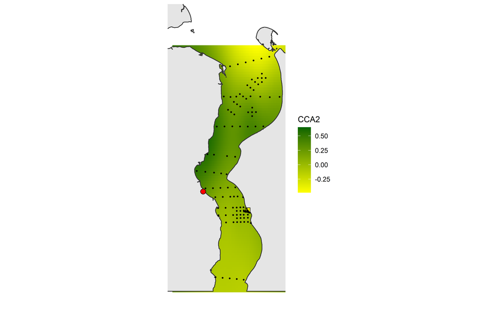

**Рисунок 8.** Распределние сообществ зоопланктона, охараткеризованных значениям второй корреспондентной оси, демонстрирующей связи с концентрацией кремния

К числу видов, характерных для таких, промежуточных, сообществ относятся:

| Таксоны |
| --- |
| Cyclopoida juv. |
| Cyclops sp. juv. |
| Cyclops vicinus |
| Drepanopus bungei |
| Euphysa flammea |
| Eurytemora affinis |
| Gammaridae |
| Leucon nasica |
| Limnocalanus grimaldii |
| Mysis oculata |
| Parasagitta elegans |
| Senecella siberica |
| Synchaeta kitina |

# Связь концентрации фитопигментов с техногенными факторами

Если техногенные факторы оказывают влияние на экосистему акватории Обской губы, то наиболее сильное влияние будет наблюдаться если к воздействию будут чувствительны нижние трофические уровни.Концентрация фитопигментов в воде может рассматриваться как приблизительная оценка интенсивности функционирования планктонных продуцентов. Для выявления связи этих характеристик с воздействием техногенных факторов, был использован анализ избыточности (Redundancy analysis, RDA). В качестве потенциальных техногенных факторов были рассмотрены *концентрация взвешенных частиц* (Suspensed_matter), *интенсивность корабельной нагрузки* (Ships), *влияние дноуглубительных работ* и *отвала грунта* (в качестве приблизительной оценки влияния этих факторов рассматривалось расстояние до точек отвала, Distance_Dump, и расстояние до точек дноуглубления, Distance_to_Drag). В полученной модели RDA первые две канонические оси были статистически значимыми (Табл. 3). Статистически значимое влияние на изучаемые величины оказывали Интенсивность корабельной нагрузки (Ships), количество взвешенного вещества (Suspended_matter) и расстояние до точек отвала грунта (Distance_Dump). Ординацию параметров фитопигментного состава в первых двух канонических осях демонстрирует (Рисунок 9). При этом сонаправленное воздействие оказывают с одной стороны концентрация взвешенных частиц и интенсивность корабельной нагрузки (отрицательная связь с RDA1), а с другой стороны - Расстояния до точек отвала и дноуглубления (положительная связь с RDA2).

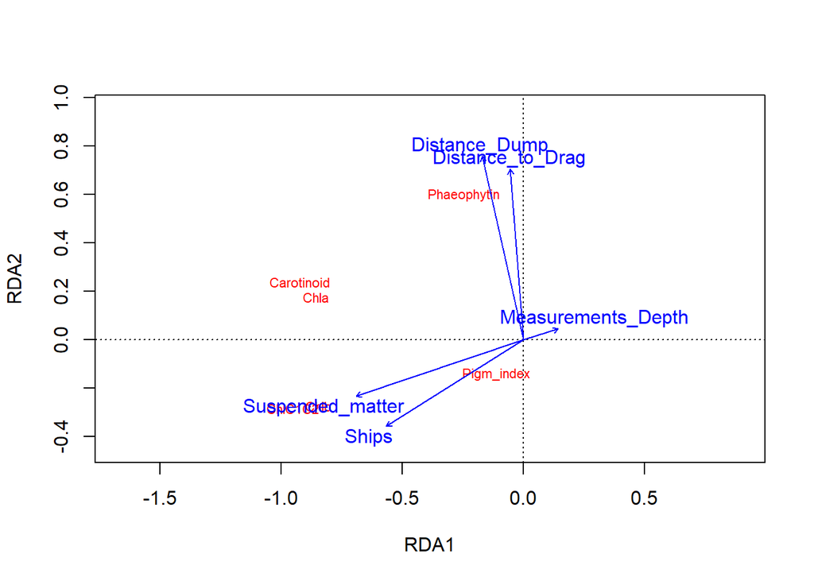

**Рисунок 9.** Ординация характеристик пигментного состава в канонических осях RDA

Таблица 3. Результаты пермутационной оценки (9999 пермутаций) статистической значимости каноанических осей RDA

| term | df | Variance | statistic | p.value |
| --- | --- | --- | --- | --- |
| RDA1 | 1 | 0.2411426 | 54.1392735 | 0.0001 |
| RDA2 | 1 | 0.0457405 | 10.2692786 | 0.0045 |
| RDA3 | 1 | 0.0026734 | 0.6002089 | 0.9644 |
| RDA4 | 1 | 0.0003141 | 0.0705286 | 0.9994 |
| RDA5 | 1 | 0.0000269 | 0.0060381 | 1.0000 |
| Residual | 268 | 1.1937029 | NA | NA |

Таблица 4. Результаты пермутационной оценки (9999 пермутаций) статистической значимости влияние отдельных предикторов в модели RDA

| term | df | Variance | statistic | p.value |
| --- | --- | --- | --- | --- |
| Ships | 1 | 0.0209007 | 4.6924421 | 0.0108 |
| Suspended_matter | 1 | 0.0807110 | 18.1205464 | 0.0001 |
| Distance_Dump | 1 | 0.0171121 | 3.8418732 | 0.0215 |
| Distance_to_Drag | 1 | 0.0010252 | 0.2301762 | 0.8429 |
| Measurements_Depth | 1 | 0.0070089 | 1.5735883 | 0.1900 |
| Residual | 268 | 1.1937029 | NA | NA |

Заметную связь с концентрацией взвешенных частиц и корабельной нагрузкой демонстрирует хлорофилл *B* и хлорофилл *С1+С2*. Чем выше концентрация взвешенных частиц, тем выше концентрация этих пигментов (Рисунок 10).

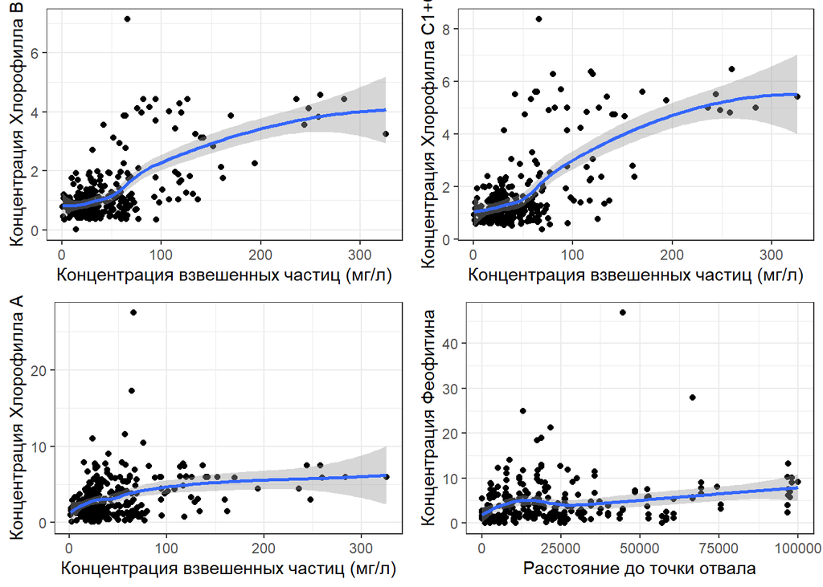

**Рисунок 10.** Зависимость концентрации фитопигментов от параметров техногенной нагрузки. Приведены аппрокимирующие LOESS регрессии.

Положительную корреляцию фитопигментов с концентрацией взвешенных частиц можно объяснить двумя способами.

1. Повышенная концентрация взвешенных частиц может коррелировать с прочими источниками антропогенного воздействия, повшающими концентрацию биогенов, что и стимулирует размножение продуцентов.
2. Взвешенные частицы могут быть субстратом, адсорбирующим фотосинтезирующих протист и прокариот.

*NB! Поверхностное гугление говорит о том, что хлорофилл B более важен при недостатке света. Хлофилл C1, кажется, характерен для диатомовых. А диатомовые это кремний. А кремний у нас дал сигнал на связи с зоопланктоном.* Нужна консультация специалиста!

*Нужно сделать общий анализ всех характеристик фитопланктона и фитопигментов, как зависимой атрицы и техногенных факторов + биогены. Пока думаю, как это посчитать.*